# Solution to Homework 8

STATS 531, Winter 2020

First, we set up a parallel computing environment which uses multiple cores on either a laptop or a slurm cluster such as Great Lakes.

```r
library(doParallel)
cluster_cores <- as.numeric(Sys.getenv('SLURM_NTASKS_PER_NODE'))
CLUSTER <- !is.na(cluster_cores)
if(CLUSTER) registerDoParallel(cluster_cores) else registerDoParallel()

library(doRNG)
registerDoRNG(1929384)
```

We now loading the data and reproduce the results in the notes12.

```r
options(
  keep.source=TRUE,
  stringsAsFactors=FALSE,
  encoding="UTF-8"
  )
library(ggplot2)
theme_set(theme_bw())
library(plyr)
library(reshape2)
library(magrittr)
library(pomp)
# bsflu_data <- read.table("http://ionides.github.io/531w20/12/bsflu_data.txt")
# read from a local copy when the internet is unreliable!
bsflu_data <- read.table("bsflu_data.txt")
bsflu_statenames <- c("S","I","R1","R2")
bsflu_paramnames <- c("Beta","mu_IR","rho","mu_R1","mu_R2")
bsflu_obsnames <- "B"

bsflu_dmeasure <- "
  lik = dpois(B,rho*R1+1e-6,give_log);
"

bsflu_rmeasure <- "
  B = rpois(rho*R1+1e-6);
"

bsflu_rprocess <- "
  double dN_SI = rbinom(S,1-exp(-Beta*I*dt));
  double dN_IR1 = rbinom(I,1-exp(-dt*mu_IR));
  double dN_R1R2 = rbinom(R1,1-exp(-dt*mu_R1));
  double dN_R2R3 = rbinom(R2,1-exp(-dt*mu_R2));
  S -= dN_SI;
  I += dN_SI - dN_IR1;
  R1 += dN_IR1 - dN_R1R2;
  R2 += dN_R1R2 - dN_R2R3;
"
bsflu_rinit <- "
 S=762;
 I=1;
 R1=0;
 R2=0;
"

bsflu2 <- pomp(
  data=subset(bsflu_data,select=c(day,B)),
  times="day",
  t0=0,
  rprocess=euler(
    step.fun=Csnippet(bsflu_rprocess),
    delta.t=1/12
  ),
  rmeasure=Csnippet(bsflu_rmeasure),
  dmeasure=Csnippet(bsflu_dmeasure),
  partrans=parameter_trans(
    log=c("Beta","mu_IR","mu_R1","mu_R2"),
    logit="rho"),
  obsnames = bsflu_obsnames,
  statenames=bsflu_statenames,
  paramnames=bsflu_paramnames,
  rinit=Csnippet(bsflu_rinit)
)

run_level <- 3
bsflu_Np <-      switch(run_level, 100, 20000, 60000)
bsflu_Nmif <-    switch(run_level,  10,   100,   300)
bsflu_Neval <-   switch(run_level,  10,    10,    10)
bsflu_Nglobal <- switch(run_level,  10,    10,   100)
bsflu_Nlocal <-  switch(run_level,  10,    10,    20)

# bsflu_params <- data.matrix(read.table("http://ionides.github.io/531w20/12/mif_bsflu_params.csv",row.names=NULL,header=TRUE))
# read from a local copy when the internet is unreliable!
bsflu_params <- data.matrix(read.table("mif_bsflu_params.csv",row.names=NULL,header=TRUE))
bsflu_mle <- bsflu_params[which.max(bsflu_params[,"logLik"]),][bsflu_paramnames]
bsflu_fixed_params <- c(mu_R1=1/(sum(bsflu_data$B)/512),mu_R2=1/(sum(bsflu_data$C)/512))


bsflu_box <- rbind(
  Beta=c(0.001,0.01),
  mu_IR=c(0.5,2),
  rho = c(0.5,1)
)

bsflu_rw.sd <- 0.02
bsflu_cooling.fraction.50 <- 0.5
stew(file=sprintf("box_eval-%d.rda",run_level),{
  t_global <- system.time({
    mifs_global <- foreach(i=1:bsflu_Nglobal,
      .packages='pomp', .combine=c) %dopar% mif2(
        bsflu2,
        params=c(apply(bsflu_box,1,function(x)runif(1,x[1],x[2])),
      bsflu_fixed_params),
        Np=bsflu_Np,
        Nmif=bsflu_Nmif,
        cooling.fraction.50=bsflu_cooling.fraction.50,
        rw.sd=rw.sd(
          Beta=bsflu_rw.sd,
          mu_IR=bsflu_rw.sd,
          rho=bsflu_rw.sd
        )
      )
    })
})

stew(file=sprintf("lik_global_eval-%d.rda",run_level),{
  t_global_eval <- system.time({
    liks_global <- foreach(i=1:bsflu_Nglobal,
      .packages='pomp',.combine=rbind) %dopar% {
        evals <- replicate(bsflu_Neval,
      logLik(pfilter(bsflu2,params=coef(mifs_global[[i]]),Np=bsflu_Np)))
          logmeanexp(evals, se=TRUE)
    }
  })
})

results_global <- data.frame(logLik=liks_global[,1],
  logLik_se=liks_global[,2],t(sapply(mifs_global,coef)))
summary(results_global$logLik,digits=5)
```

```
##    Min. 1st Qu.  Median    Mean 3rd Qu.    Max.
##  -75.77  -74.59  -74.25  -74.26  -73.97  -73.00
```

```r
t_global
```

```
##       user     system    elapsed
## 118781.432    326.499   5109.939
```

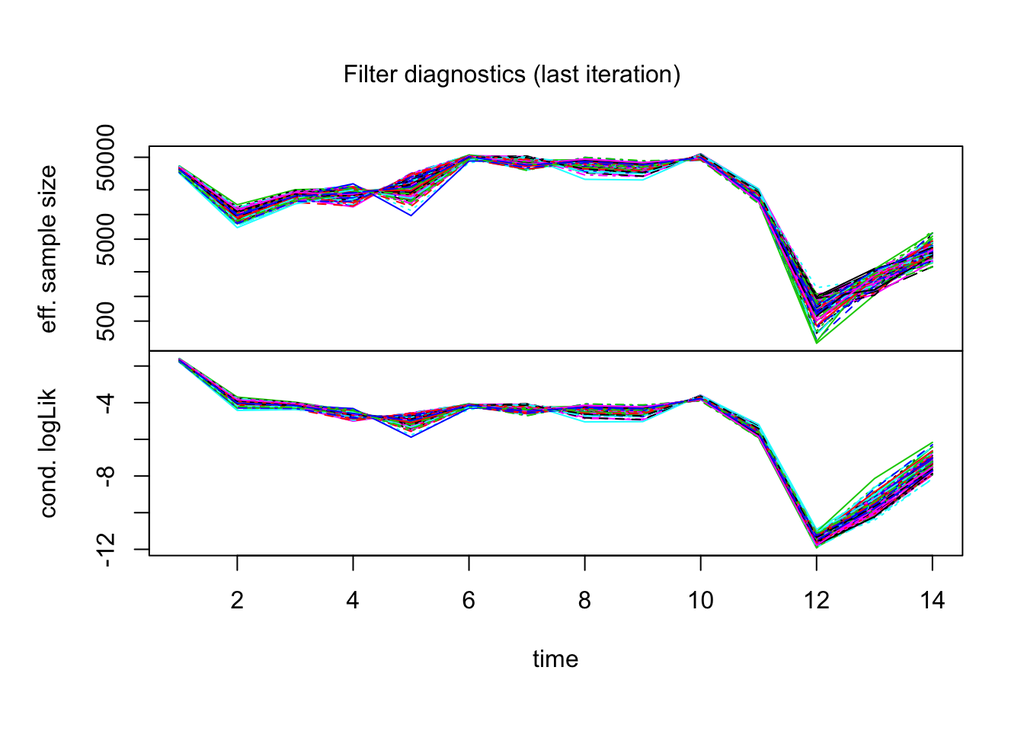

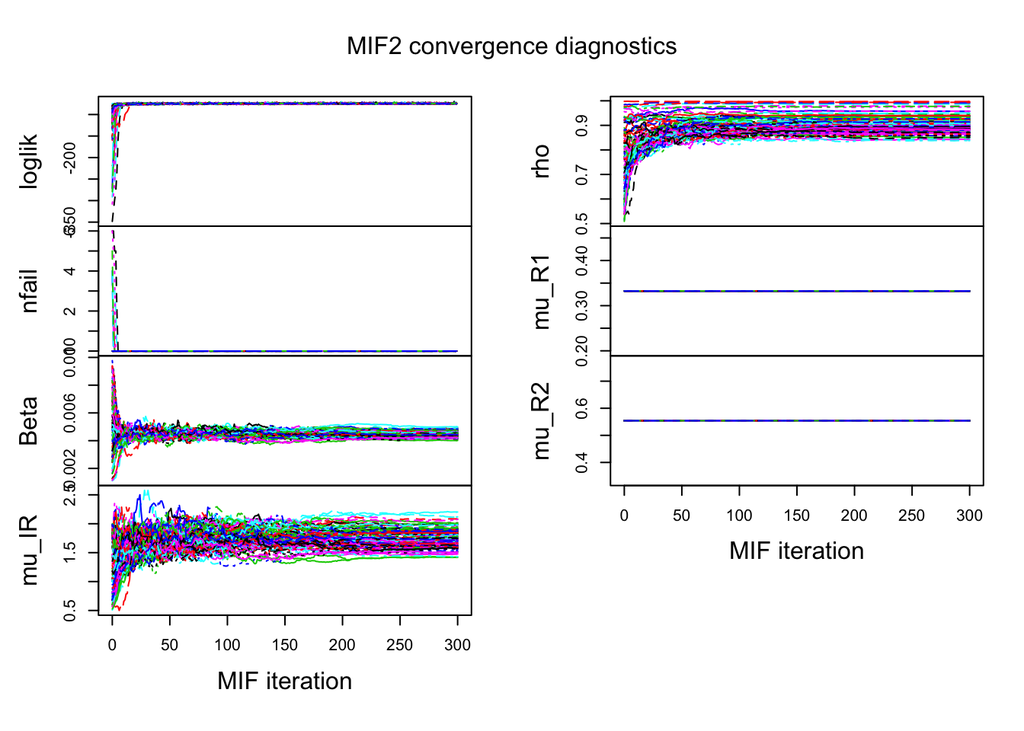

```r
plot(mifs_global)
```

**Question 8.1**. Assessing and improving algorithmic parameters.

From the diagnostic plots above, at run level 3, we can see the effective sample sizes are basically large (except the time point with less than 500 effective sample size) and all the parameters are converged after 200 MIF iteration. Since this run level takes considerable computational resources, we investigate whether we can get comparable results for half the effort.

In the following code, we test a new set of algorithmic parameters.

```r
run_level <- 4
bsflu_Np <-      switch(run_level, 100, 20000, 60000, 50000)
bsflu_Nmif <-    switch(run_level,  10,   100,   300,   250)
bsflu_Neval <-   switch(run_level,  10,    10,    10,    10)
bsflu_Nglobal <- switch(run_level,  10,    10,   100,    75)
bsflu_Nlocal <-  switch(run_level,  10,    10,    20,    20)
bsflu_cooling.fraction.50 <- 0.6
```

We will change the number of particles (`Np`) to $5\times 10^{4}$, the number of the MIF iteration (`Nmif`) to $250$, and the number of global searches to $75$. Moreover, we will change `bsflu_cooling.fraction.50` to $0.6$. Our hypothesis is that these changes can reduce the computation time and give us satisfactory convergence with acceptable effective sample sizes.

```r
stew(file=sprintf("Mif-8.1-%d.rda",run_level),{

  t_global.2 <- system.time({
    mifs_global.2 <- foreach(i=1:bsflu_Nglobal,
      .packages='pomp', .combine=c) %dopar%
      mif2(
        mifs_global[[1]],
        start=c(apply(bsflu_box,1,function(x)runif(1,x[1],x[2])),bsflu_fixed_params),
        Np=bsflu_Np,
        Nmif=bsflu_Nmif,
        cooling.fraction.50=bsflu_cooling.fraction.50
      )
  })
})
##----eval llh--------

stew(file=sprintf("lik-8.1-%d.rda",run_level),{
  t_global_eval.2 <- system.time({
    liks_global.2 <- foreach(i=1:bsflu_Nglobal,
      .packages='pomp',.combine=rbind) %dopar% {
      evals <- replicate(bsflu_Neval,
        logLik(pfilter(bsflu2,params=coef(mifs_global.2[[i]]),Np=bsflu_Np)))
      logmeanexp(evals, se=TRUE)
    }
  })
})
t_global.2
```

```
##      user    system   elapsed
## 61596.856   291.778  2620.883
```

```r
results_global.2 <- data.frame(logLik=liks_global.2[,1],
  logLik_se=liks_global.2[,2],t(sapply(mifs_global.2,coef)))
summary(results_global.2$logLik,digits=5)
```

```
##    Min. 1st Qu.  Median    Mean 3rd Qu.    Max.
##  -75.33  -74.48  -74.24  -74.12  -73.73  -72.53
```

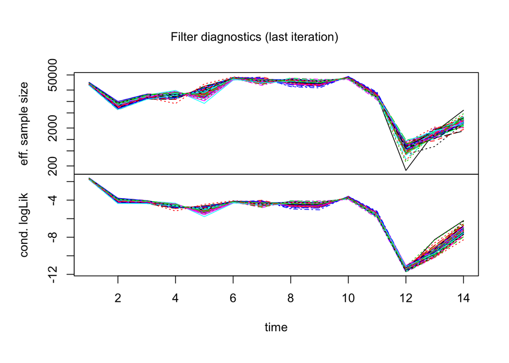

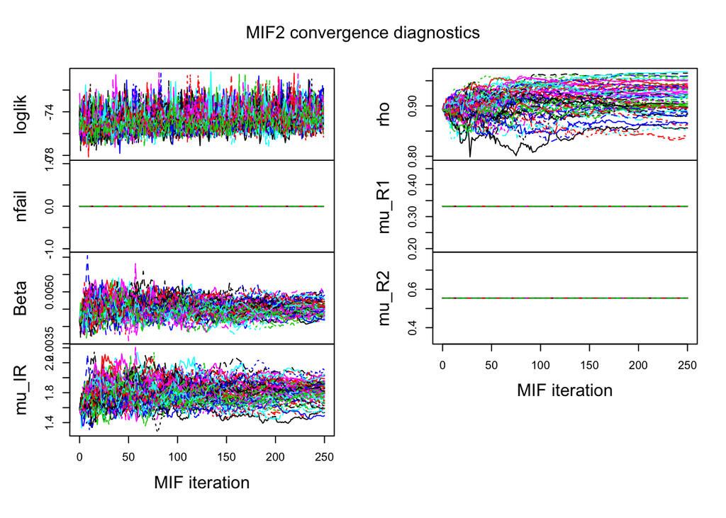

```r
plot(mifs_global.2)
```

- We can see, this change reduce the time since less computations are needed. The total time taken reduced from 85.2 minutes to 43.7 minutes. The reduced search maybe shows some additional Monte Carlo variation in the convergence plots, but not dramatically. It found a better maximized likelihood, -72.53.
- The effective sample sizes are large and basically the same as before, so it is still acceptable.
- $\beta$ and $\rho$ are converged in most of the particles. There are only few particles in which $\mu_{IR}$ is not converged.

**Question 8.2**. Finding sharp peaks in the likelihood surface.

The drawing method with scale invariant properties is: First,taking logarithm of the orginal domain. Secondly, drawing sample uniformly from it. Thirdly, taking exponetiation of the sample.

In `R`, we can implement with command `exp(runif(1,log(a),log(b)))`, where (a,b) is the orginal domain.

Following is the code the implements this drawing method (only for $\beta$).

```r
stew(file=sprintf("box_eval_log new-%d.rda",run_level),{
    t_global.3 <- system.time({
    mifs_global.3 <- foreach(i=1:bsflu_Nglobal,
      .packages='pomp', .combine=c) %dopar%
      mif2(
        mifs_global[[1]],
        params=c(Beta=exp(runif(1,log(bsflu_box[1,1]),log(bsflu_box[1,2])))
           ,apply(bsflu_box[2:3,],1,function(x)
         runif(1,x[1],x[2])),bsflu_fixed_params),
        Np=bsflu_Np,
        Nmif=bsflu_Nmif
      )
  })
})

stew(file=sprintf("lik_global_eval_log new-%d.rda",run_level),{
  t_global_eval.3 <- system.time({
    liks_global.3 <- foreach(i=1:bsflu_Nglobal,
      .packages='pomp',.combine=rbind) %dopar% {
      evals <- replicate(bsflu_Neval, logLik(
        pfilter(bsflu2,params=coef(mifs_global.3[[i]]),Np=bsflu_Np)))
      logmeanexp(evals, se=TRUE)
    }
  })
})

results_global.3 <- data.frame(logLik=liks_global.3[,1],
  logLik_se=liks_global.3[,2],t(sapply(mifs_global.3,coef)))
summary(results_global.3$logLik,digits=5)
```

```
##    Min. 1st Qu.  Median    Mean 3rd Qu.    Max.
##  -75.50  -74.75  -74.44  -74.37  -74.10  -72.33
```

Comparing this result with the ones above, we can see this method does not help much in the optimization. The median log likelihood value found by the search is lower than before. However, it has led to a small further improvement in the maximized log likelihood, to -72.33.

To illustrate the difference between the two approaches, we can look at the following histograms of 5000 samples with the two drawing methods.

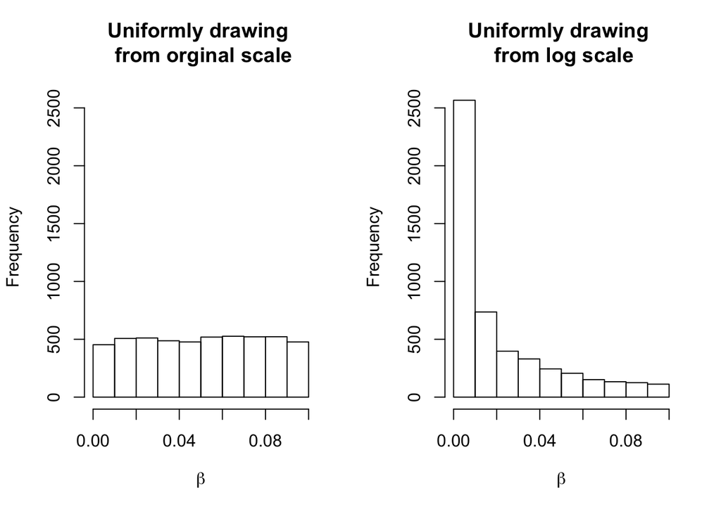

```r
par(mfrow=c(1,2))
hist(runif(5000,0.001,0.1),ylim=c(0,2600),xlab=expression(beta),
     main="Uniformly drawing \n from orginal scale")
hist(exp(runif(5000,log(0.001),log(0.1))),xlab=expression(beta),
     ylim=c(0,2600),
     main="Uniformly drawing \n from log scale")
```

The density around the MLE ($\beta \approx 0.004$) is higher for the log scale search.

**Question 8.3**. Construct a profile likelihood.

First, we construct a parameter box for computing the profile likelihood of $\beta$.

```r
profile_run_level <- 3
bsflu_profile_pts <- switch(profile_run_level, 5,10,30)
bsflu_profile_reps <- switch(profile_run_level, 3,10,20)
bsflu_profile_Np_mif <- switch(profile_run_level, 100,1000,5000)
bsflu_profile_Nmif <- switch(profile_run_level, 2,20,100)
bsflu_profile_Neval <- switch(profile_run_level, 10,10,10)
bsflu_profile_Np_eval <- switch(profile_run_level, 100,1000,10000)

profile.starts <- profileDesign(
  Beta=exp(seq(log(0.001),log(0.01),length.out=bsflu_profile_pts)),
  lower=c(mu_IR=0.5,rho=0.5),
  upper=c(mu_IR=2,rho=1),
  nprof=bsflu_profile_reps
)
```

Then, from each start point, we use `mif2` to find the maximized likelihood and the correponding MLE. Since we need to find the profile likelihood of $\beta$, we need to fix it during the iterated filtering. Therefore, only $\mu_{IR}$ and $\rho$ have random walk stand deviation (`rw.sd`).

```r
stew(file=sprintf("profile_beta-%d.rda",profile_run_level),{
  t_global.4 <- system.time({
      prof.llh<- foreach(start=iter(profile.starts,"row"),
        .combine=rbind) %dopar%{
        # Find MLE
        mif2(
          mifs_global[[1]],
          params=c(start,bsflu_fixed_params),
          Np=bsflu_profile_Np_mif,
      Nmif=bsflu_profile_Nmif,
          rw.sd=rw.sd(
            mu_IR=bsflu_rw.sd,
            rho=bsflu_rw.sd
          )
        )->mifs_global.4
        # evaluate llh
        evals = replicate(bsflu_profile_Neval,logLik(pfilter(mifs_global.4,
      Np=bsflu_profile_Np_eval)))
        ll=logmeanexp(evals, se=TRUE)

        data.frame(as.list(coef(mifs_global.4)),
                   loglik = ll[1],
                   loglik.se = ll[2])
      }
  })
})
```

Finally, for each value of $\beta$, we use the MLE of the largest likelihood to construct the profile likelihood. The `loess` method is used to fit an estimate of the profile through these points. An approximate 95% confidence interval of $\beta$ is $\{\beta: \max[\ell^{profile}(\beta)]-\ell^{profile}(\beta)<1.92\}$

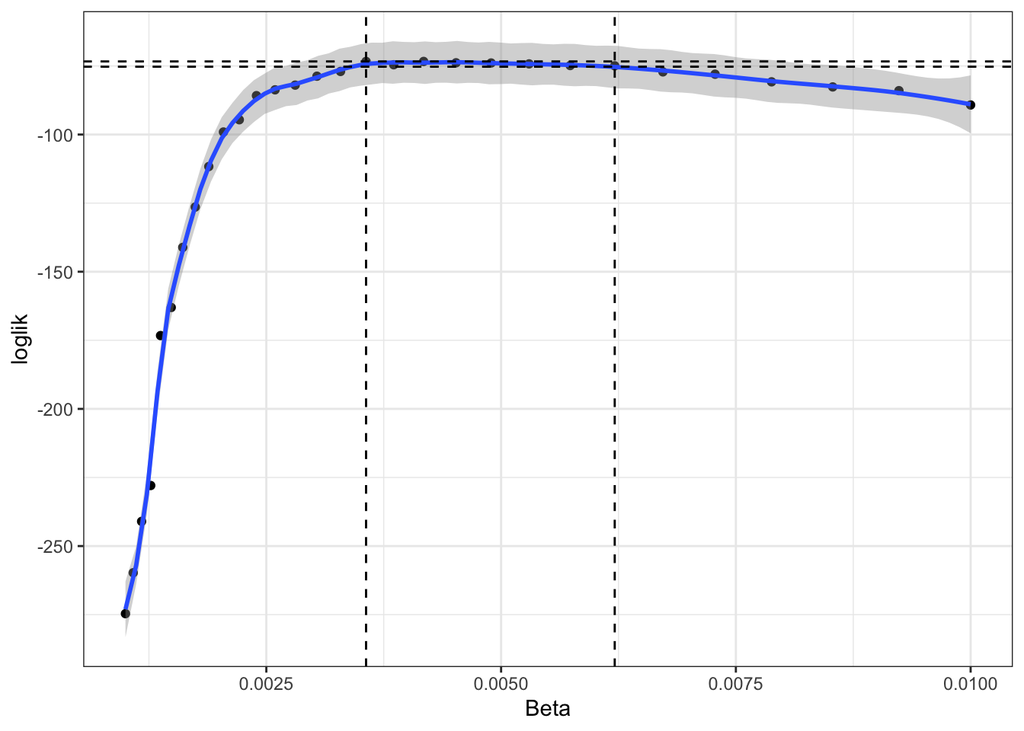

```r
prof.llh %>%
  mutate(Beta=exp(signif(log(Beta),5))) %>%
  ddply(~Beta,subset,rank(-loglik)<=1) -> prof.max

aa=max(prof.max$loglik)
bb=aa-1.92
CI=which(prof.max$loglik>=bb)
cc=prof.max$Beta[min(CI)]
dd=prof.max$Beta[max(CI)]


prof.max %>%
  ggplot(aes(x=Beta,y=loglik))+
  geom_point()+
  geom_smooth(method="loess",span=0.2)+
  geom_hline(aes(yintercept=aa),linetype="dashed")+
  geom_hline(aes(yintercept=bb),linetype="dashed")+
  geom_vline(aes(xintercept=cc),linetype="dashed")+
  geom_vline(aes(xintercept=dd),linetype="dashed")
```

```r
c(lower=cc,upper=dd)
```

```
##       lower       upper
## 0.003562118 0.006209965
```

As we can see, the 95% confidence interval of $\beta$ is $[0.00356, 0.00621]$, which shows the uncertainty in our understanding of the contact rate for influenza in this population, taking into account our uncertainty about other parameters.

**Question 8.4**.

All responses were given full credit as long as they were consistent with the solutions presented.

### Acknowledgements

Parts of this solution are adapted from a previous homework submission by Rui Zhang.